# Predicting the Risk of having a Low Birth Weight (Low)

1. Low Birth Weight Data
2. Loading Libraries
3. Accessing data
4. Exploring data
5. Parsing Function for the data
6. Splitting the data into a training and test set
7. Building Model
8. Predicting for the Test Data set
9. Evaluating the Model
10. ROC Curve Plot

## Loading Libraries

We need to load the preinstalled Spark and Python libraries that are already present in the notebook environment.

To load the libraries we will run the following cell:

```python
# PySpark Machine Learning Library
from pyspark.ml import Pipeline
from pyspark.ml.classification import LogisticRegression
from pyspark.ml.classification import  NaiveBayes, MultilayerPerceptronClassifier
from pyspark.ml.feature import HashingTF, Tokenizer
from pyspark.sql import Row, SQLContext

import os
import sys
from pyspark import SparkConf
from pyspark import SparkContext
from pyspark.sql import SQLContext
from pyspark.sql.types import *

from pyspark.mllib.classification import LogisticRegressionWithSGD
from pyspark.mllib.regression import LabeledPoint
from numpy import array

from pyspark.ml.evaluation import MulticlassClassificationEvaluator
# Library for confusion matrix, precision, test error
from pyspark.mllib.evaluation import MulticlassMetrics
# Library For Area under ROC curve and Area under precision-recall curve
from pyspark.mllib.evaluation import BinaryClassificationMetrics

# Assign resources to the application
sqlContext = SQLContext(sc)

# packages for data analysis
import numpy as np
import pandas as pd
```

```python
# The data will be loaded into an array.
# This is the summary of the data structure, including the column position and name.
# The first filed starts from position 0.

#0. ID - Identification Code of Babies
#1. LOW - Low birth weight (0: >= 2500, 1: < 2500 g) -  target variablE
#2. AGE - Mothers age in years
#3. RACE - Race (1: White, 2:Black, 3:Other)
#4. SMOKE - Smoking status during pregnancy (1:No, 2:Yes)
#5. PTL - History of premature labor (1: None, 2:One, 3:Two, etc)
#6. HT - History of hypertension (1:No, 2:Yes)
#7. UI - Presence of Uterine irritablility (1:No, 2:Yes)
#8. FTV - Number of Physician visit during the first trimester (1:None, 2:One, 3:Two, etc)

# Label is a target variable. BabyInfo is a list of independent variables besides unique identifier (BabyID)

LabeledDocument = Row("PersonID", "PersonInfo", "label")

# Define a function that parses each row CSV file and returns an object of type LabeledDocument

def parseDocument(line):
    values = [str(x) for x in line.split(',')]
    if (values[1]>'0'):
      LOW = 1.0
    else:
      LOW = 0.0

    textValue = str(values[3]) + " " + str(values[4])+" " + str(values[5]) + " " + str(values[6])+" " +  str(values[7])+" " + str(values[8])
    return LabeledDocument(values[0], textValue, LOW)
```

## Accessing data

Let's configure Spark using our Object Storage credentials before we access the data in the data file in the Object Storage.

We need to click on the cell below and choose the **Insert to code > Insert Spark Session DataFrame** function from the Files tab underneath the data file to accomplish this.

```python
import ibmos2spark, os
# @hidden_cell
metadata = {
    'endpoint': 'https://s3.private.us.cloud-object-storage.appdomain.cloud',
    'service_id': 'iam-ServiceId-a9d74bf8-d8d2-4fc2-97cf-75dc39b4c1fc',
    'iam_service_endpoint': 'https://iam.cloud.ibm.com/oidc/token',
    'api_key': 'rLwN9OT4fjTlUuDPPzg1C3DAeNsFiTBzgf7iOT5BF15F'
}

configuration_name = 'os_95def7c018954c158943752a4c6585b2_configs'
cos = ibmos2spark.CloudObjectStorage(sc, metadata, configuration_name, 'bluemix_cos')

from pyspark.sql import SparkSession
spark = SparkSession.builder.getOrCreate()
df_data_1 = spark.read\
  .format('org.apache.spark.sql.execution.datasources.csv.CSVFileFormat')\
  .option('header', 'true')\
  .option('inferSchema', 'true')\
  .load(cos.url('lowbwt.csv', 'apachesparktutorial-donotdelete-pr-smb3ezagontwns'))
df_data_1.take(5)
```

```
[Row(ID=85, LOW=0, AGE=19, RACE=2, SMOKE=0, PTL=0, HT=0, UI=1, FTV=0),
 Row(ID=86, LOW=0, AGE=33, RACE=3, SMOKE=0, PTL=0, HT=0, UI=0, FTV=3),
 Row(ID=87, LOW=0, AGE=20, RACE=1, SMOKE=1, PTL=0, HT=0, UI=0, FTV=1),
 Row(ID=88, LOW=0, AGE=21, RACE=1, SMOKE=1, PTL=0, HT=0, UI=1, FTV=2),
 Row(ID=89, LOW=0, AGE=18, RACE=1, SMOKE=1, PTL=0, HT=0, UI=1, FTV=0)]
```

```python
# Object Storage Credentials
```

## Exploring data

```python
print('Number of Babies', df_data_1.count())
```

```
Number of Babies 189
```

```python
#Number of Babies who have >= 2500, and < 2500 g
df_data_1.groupby('LOW').count().show()
```

```
+---+-----+
|LOW|count|
+---+-----+
|  1|   59|
|  0|  130|
+---+-----+
```

```
+--------+---+---+
|RACE_LOW|  0|  1|
+--------+---+---+
|       1| 73| 23|
|       3| 42| 25|
|       2| 15| 11|
+--------+---+---+
```

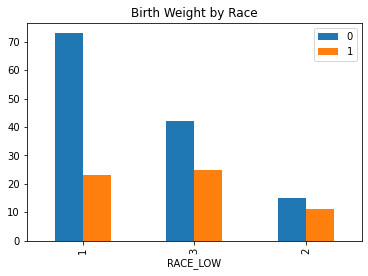

```python
#Number of Babies who have >= 2500, and < 2500 g by their RACE
%matplotlib inline
df_data_1.crosstab('RACE', 'LOW').show()
df=df_data_1.crosstab('RACE', 'LOW').toPandas()
df.plot.bar(x="RACE_LOW", legend=True, title="Birth Weight by Race")
```

```python
# Average age by Weight outcome
pdf=df_data_1.toPandas()
pdf["AGE"]=pd.to_numeric(pdf.AGE)

df=sqlContext.createDataFrame(pdf)

PAGE=df.groupby(['LOW'])\
.agg({"AGE": "AVG"}).toPandas()
PAGE
```

|  | LOW | avg(AGE) |
| --- | --- | --- |
| 0 | 0 | 23.661538 |
| 1 | 1 | 22.305085 |

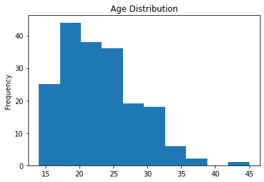

```python
#Age Distribution for all Babies
df.toPandas()["AGE"].plot.hist(x="AGE", title="Age Distribution")
```

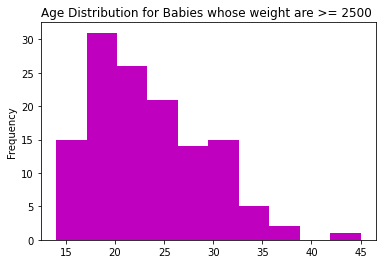

```python
#Age distribution for Babies whose weights are >= 2500
df_LOW=df.select('AGE', 'LOW').filter(df['LOW']=='0')
pdf_LOW=df_LOW.select('AGE').toPandas()
pdf_LOW.plot.hist('AGE', color='m', legend=False, title="Age Distribution for Babies whose weight are >= 2500 ")
```

## Parsing Function for the data

Let's now input the data into a Spark RDD and output the total number of rows as well as the first five rows.

```python
data = sc.textFile(cos.url('lowbwt.csv', 'apachesparktutorial-donotdelete-pr-smb3ezagontwns'))
print ("Total records in the data set:", data.count())
print ("The first 5 rows")
data.take(5)
```

```
Total records in the data set: 190
The first 5 rows
```

```
['ID,LOW,AGE,RACE,SMOKE,PTL,HT,UI,FTV',
 '85,0,19,2,0,0,0,1,0',
 '86,0,33,3,0,0,0,0,3',
 '87,0,20,1,1,0,0,0,1',
 '88,0,21,1,1,0,0,1,2']
```

#### Creating DataFrame from RDD

```python
#Parsing and Loading the data into a dataframe. The code will calls the parsing function defined above
documents = data.filter(lambda s: "ID" not in s).map(parseDocument)
lowbwtData = documents.toDF() #ToDataFrame
print ("Number of records: " + str(lowbwtData.count()))
print ( "First 5 records: ")
lowbwtData.take(5)
#I need to change Name to ID
```

```
Number of records: 189
First 5 records:
```

```
[Row(PersonID='85', PersonInfo='2 0 0 0 1 0', label=0.0),
 Row(PersonID='86', PersonInfo='3 0 0 0 0 3', label=0.0),
 Row(PersonID='87', PersonInfo='1 1 0 0 0 1', label=0.0),
 Row(PersonID='88', PersonInfo='1 1 0 0 1 2', label=0.0),
 Row(PersonID='89', PersonInfo='1 1 0 0 1 0', label=0.0)]
```

# Splitting the data into a training and test set

Splitting data into train and test helps us to evaluate the performance of the model that has been trained on the training data, by testing it on the unseen test data. By dividing the data into train and test, we can train the model on one the set and use the other set to evaluate the model's accuracy and make predictions which also helps preventing overfitting.

```python
# Dividing the data into train and test sets
(train, test) = lowbwtData.randomSplit([0.8,0.2])
print("Number of records in the train set: " + str(train.count()))
print("Number of records in the test set: " + str(test.count()))
#Output the first 20 records in the training set
print("First 20 records in the training set: ")
train.show()
```

```
Number of records in the train set: 152
Number of records in the test set: 37
First 20 records in the training set:
+--------+-----------+-----+
|PersonID| PersonInfo|label|
+--------+-----------+-----+
|     100|1 1 0 0 0 0|  0.0|
|     102|2 0 0 0 0 0|  0.0|
|     103|1 1 0 0 0 3|  0.0|
|     105|1 1 0 0 0 1|  0.0|
|     107|1 0 0 0 1 3|  0.0|
|     108|1 0 0 0 0 1|  0.0|
|     109|3 0 0 0 0 0|  0.0|
|     111|3 0 0 0 1 2|  0.0|
|     113|1 1 0 0 0 0|  0.0|
|     114|1 0 0 0 0 2|  0.0|
|     115|2 1 0 0 0 0|  0.0|
|     116|2 0 0 0 0 1|  0.0|
|     117|2 0 0 0 0 1|  0.0|
|     118|1 1 1 0 0 1|  0.0|
|     119|2 1 1 0 0 1|  0.0|
|     120|1 0 0 0 0 1|  0.0|
|     121|2 0 0 0 0 0|  0.0|
|     123|1 1 0 0 0 2|  0.0|
|     124|1 1 0 0 0 2|  0.0|
|     125|1 1 0 0 0 0|  0.0|
+--------+-----------+-----+
only showing top 20 rows
```

# Building the Logistic Regression Model

TO build the Logistic Regression Model, the Pipeline of SparkML is used

```python
#settin up Logistic Regression using Pipe
tokenizer = Tokenizer(inputCol="PersonInfo", outputCol="words")
hashingTF = HashingTF(inputCol=tokenizer.getOutputCol(), outputCol="features")
lr = LogisticRegression(maxIter=10, regParam=0.01)
pipeline = Pipeline(stages=[tokenizer, hashingTF, lr])
```

```python
# setting up Logistic Regression Model in which stages are executed in order
model = pipeline.fit(train)
#[stage.coefficients for stage in model.stages if hasattr(stage, "coefficients)]")]
#model.stages[2].intercept
```

# Predicting for the Test Data set

```python
#Making predictions for the test data and print columns of interest
prediction = model.transform(test)
selected = prediction.select("PersonInfo", "prediction", "probability")
for row in selected.collect():
    print (row)
```

```
Row(PersonInfo='1 1 0 0 0 0', prediction=0.0, probability=DenseVector([0.8038, 0.1962]))
Row(PersonInfo='3 0 0 0 1 0', prediction=0.0, probability=DenseVector([0.6285, 0.3715]))
Row(PersonInfo='3 0 0 0 0 2', prediction=0.0, probability=DenseVector([0.6454, 0.3546]))
Row(PersonInfo='1 0 0 0 0 0', prediction=0.0, probability=DenseVector([0.8924, 0.1076]))
Row(PersonInfo='3 0 0 0 0 0', prediction=0.0, probability=DenseVector([0.774, 0.226]))
Row(PersonInfo='1 1 0 0 0 2', prediction=0.0, probability=DenseVector([0.6853, 0.3147]))
Row(PersonInfo='3 0 0 0 0 0', prediction=0.0, probability=DenseVector([0.774, 0.226]))
Row(PersonInfo='3 0 0 0 0 0', prediction=0.0, probability=DenseVector([0.774, 0.226]))
Row(PersonInfo='3 1 0 0 0 6', prediction=1.0, probability=DenseVector([0.494, 0.506]))
Row(PersonInfo='1 1 1 0 0 4', prediction=1.0, probability=DenseVector([0.4708, 0.5292]))
Row(PersonInfo='3 0 0 0 0 0', prediction=0.0, probability=DenseVector([0.774, 0.226]))
Row(PersonInfo='3 0 0 0 0 0', prediction=0.0, probability=DenseVector([0.774, 0.226]))
Row(PersonInfo='1 0 0 0 0 0', prediction=0.0, probability=DenseVector([0.8924, 0.1076]))
Row(PersonInfo='1 0 0 0 0 1', prediction=0.0, probability=DenseVector([0.8038, 0.1962]))
Row(PersonInfo='3 0 0 0 0 2', prediction=0.0, probability=DenseVector([0.6454, 0.3546]))
Row(PersonInfo='1 1 0 1 0 0', prediction=0.0, probability=DenseVector([0.6693, 0.3307]))
Row(PersonInfo='1 1 0 0 0 1', prediction=0.0, probability=DenseVector([0.6693, 0.3307]))
Row(PersonInfo='1 1 0 0 1 2', prediction=0.0, probability=DenseVector([0.5183, 0.4817]))
Row(PersonInfo='1 0 0 0 0 1', prediction=0.0, probability=DenseVector([0.8038, 0.1962]))
Row(PersonInfo='3 0 0 0 0 1', prediction=0.0, probability=DenseVector([0.6285, 0.3715]))
Row(PersonInfo='1 1 0 0 0 0', prediction=0.0, probability=DenseVector([0.8038, 0.1962]))
Row(PersonInfo='1 0 0 0 0 1', prediction=0.0, probability=DenseVector([0.8038, 0.1962]))
Row(PersonInfo='1 0 0 0 0 1', prediction=0.0, probability=DenseVector([0.8038, 0.1962]))
Row(PersonInfo='3 0 0 0 0 0', prediction=0.0, probability=DenseVector([0.774, 0.226]))
Row(PersonInfo='3 0 0 0 0 1', prediction=0.0, probability=DenseVector([0.6285, 0.3715]))
Row(PersonInfo='1 1 0 0 0 0', prediction=0.0, probability=DenseVector([0.8038, 0.1962]))
Row(PersonInfo='1 1 0 0 0 2', prediction=0.0, probability=DenseVector([0.6853, 0.3147]))
Row(PersonInfo='3 0 0 0 0 0', prediction=0.0, probability=DenseVector([0.774, 0.226]))
Row(PersonInfo='1 0 0 0 0 2', prediction=0.0, probability=DenseVector([0.8151, 0.1849]))
Row(PersonInfo='1 1 0 0 0 0', prediction=0.0, probability=DenseVector([0.8038, 0.1962]))
Row(PersonInfo='1 1 1 0 0 1', prediction=0.0, probability=DenseVector([0.5, 0.5]))
Row(PersonInfo='1 0 0 0 0 0', prediction=0.0, probability=DenseVector([0.8924, 0.1076]))
Row(PersonInfo='2 1 0 0 0 0', prediction=0.0, probability=DenseVector([0.8151, 0.1849]))
Row(PersonInfo='1 1 0 0 0 1', prediction=0.0, probability=DenseVector([0.6693, 0.3307]))
Row(PersonInfo='3 0 0 0 0 3', prediction=1.0, probability=DenseVector([0.4113, 0.5887]))
Row(PersonInfo='3 0 0 0 0 2', prediction=0.0, probability=DenseVector([0.6454, 0.3546]))
Row(PersonInfo='2 0 0 1 0 0', prediction=0.0, probability=DenseVector([0.8151, 0.1849]))
```

```python
#Tabulate the predicted outcome
prediction.select("prediction").groupBy("prediction").count().show(truncate=False)
```

```
+----------+-----+
|prediction|count|
+----------+-----+
|0.0       |34   |
|1.0       |3    |
+----------+-----+
```

```python
#Tabulating the actual outcome
prediction.select("label").groupBy("label").count().show(truncate=False)
```

```
+-----+-----+
|label|count|
+-----+-----+
|0.0  |25   |
|1.0  |12   |
+-----+-----+
```

```python
# This table shows Predicted number of Babies:
#whose weight is less than 2500g
#greater than or equal to 2500g

prediction.crosstab('label', 'prediction').show()
```

```
+----------------+---+---+
|label_prediction|0.0|1.0|
+----------------+---+---+
|             1.0| 11|  1|
|             0.0| 23|  2|
+----------------+---+---+
```

# Evaluating the Model

Evaluating the model on the training and test sets. Evaluating the model is important to determine its accuracy, reliability, and effectiveness in making predictions based on the data.

```python
# Evaluating the Logistic Regression model on the training set
#select (prediction, true label) and compute test error
pred_lr=model.transform(train).select("prediction", "label")
eval_lr=MulticlassClassificationEvaluator (
    labelCol="label", predictionCol="prediction", metricName="accuracy")
accuracy_lr=eval_lr.evaluate(pred_lr)
#create RDD
predictionAndLabels_lr=pred_lr.rdd
metrics_lr=MulticlassMetrics(predictionAndLabels_lr)
precision_lr=metrics_lr.precision(1.0)
recall_lr=metrics_lr.recall(1.0)
f1Measure_lr = metrics_lr.fMeasure(1.0, 1.0)
print ("Model evaluation for the training data")
print ("Accuracy = %s" %accuracy_lr)
print ("Error = %s" % (1-accuracy_lr))
print ("Precision = %s" %precision_lr)
print ("Recall = %s" %recall_lr)
print ("F1 Measure = %s" % f1Measure_lr)
```

```
Model evaluation for the training data
Accuracy = 0.7105263157894737
Error = 0.2894736842105263
Precision = 0.56
Recall = 0.2978723404255319
F1 Measure = 0.3888888888888889
```

```python
# Evaluating the Logistic Regression model on the test set
#select (prediction, true label) and compute test error
pred_lr=model.transform(test).select("prediction", "label")
eval_lr=MulticlassClassificationEvaluator (
    labelCol="label", predictionCol="prediction", metricName="accuracy")
accuracy_lr=eval_lr.evaluate(pred_lr)
#create RDD
predictionAndLabels_lr=pred_lr.rdd
metrics_lr=MulticlassMetrics(predictionAndLabels_lr)
precision_lr=metrics_lr.precision(1.0)
recall_lr=metrics_lr.recall(1.0)
f1Measure_lr = metrics_lr.fMeasure(1.0, 1.0)
print ("Model evaluation for the testing data")
print ("Accuracy = %s" %accuracy_lr)
print ("Error = %s" % (1-accuracy_lr))
print ("Precision = %s" %precision_lr)
print ("Recall = %s" %recall_lr)
print ("F1 Measure = %s" % f1Measure_lr)
```

```
Model evaluation for the testing data
Accuracy = 0.6486486486486487
Error = 0.3513513513513513
Precision = 0.3333333333333333
Recall = 0.08333333333333333
F1 Measure = 0.13333333333333333
```

```python
bin_lr=BinaryClassificationMetrics(predictionAndLabels_lr)

#area under precision-recall curve
print("Area under PR = %s" % bin_lr.areaUnderPR)
#area under receiver operating characteristic curve
print ("Area under ROC = %s" % bin_lr.areaUnderROC)
```

```
Area under PR = 0.32920420420420415
Area under ROC = 0.5016666666666666
```

# ROC Curve Plot

The ROC curve helps us to observe the model's performace across all possible classification thresholds which is used to visualize the trade-off between the truee positive rate and the false positive rate at different thresholds.

```python
#The first 20 ROC curve points
model.stages[2].summary.roc.show()
```

```
+-------------------+-------------------+
|                FPR|                TPR|
+-------------------+-------------------+
|                0.0|                0.0|
|0.01904761904761905| 0.0851063829787234|
|0.02857142857142857| 0.0851063829787234|
|0.02857142857142857|0.10638297872340426|
| 0.0380952380952381|0.10638297872340426|
| 0.0380952380952381| 0.1276595744680851|
| 0.0761904761904762| 0.2553191489361702|
|0.10476190476190476| 0.2978723404255319|
|0.11428571428571428| 0.3404255319148936|
|0.13333333333333333| 0.3617021276595745|
|                0.2|0.48936170212765956|
|0.21904761904761905|0.48936170212765956|
| 0.3142857142857143| 0.5957446808510638|
|0.37142857142857144|  0.723404255319149|
| 0.3904761904761905| 0.7446808510638298|
| 0.5142857142857142| 0.8723404255319149|
| 0.5238095238095238| 0.8723404255319149|
| 0.5333333333333333| 0.8723404255319149|
| 0.7428571428571429| 0.9148936170212766|
| 0.8761904761904762| 0.9574468085106383|
+-------------------+-------------------+
only showing top 20 rows
```

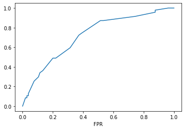

```python
import matplotlib.pyplot as plt
%matplotlib inline
ROC=model.stages[2].summary.roc
df=ROC.toPandas()

df.plot(x='FPR', y='TPR', legend=False)
```